# Risk Factor Analysis

## Outcome Variable

**Outcome Variable:** y_rate_haz

## Predictor Variables

**Intervention Variable:** nchldlt5

**Adjustment Set:**

- arm
- W_mage
- meducyrs
- feducyrs
- hhwealth_quart
- hfoodsec
- W_mhtcm
- W_mwtkg
- W_mbmi
- W_nrooms
- W_parity
- impfloor
- impsan
- safeh20
- delta_W_mage
- delta_meducyrs
- delta_feducyrs
- delta_hhwealth_quart
- delta_hfoodsec
- delta_W_mhtcm
- delta_W_mwtkg
- delta_W_mbmi
- delta_W_nrooms
- delta_W_parity
- delta_impfloor
- delta_impsan
- delta_safeh20

## Stratifying Variables

The analysis was stratified on these variable(s):

- agecat
- studyid
- country

## Data Summary

| agecat | studyid | country | nchldlt5 | n_cell | n |
| --- | --- | --- | --- | --- | --- |
| 0-3 months | IRC | INDIA | 1 | 82 | 377 |
| 0-3 months | IRC | INDIA | 2+ | 295 | 377 |
| 0-3 months | JiVitA-3 | BANGLADESH | 1 | 12370 | 19860 |
| 0-3 months | JiVitA-3 | BANGLADESH | 2+ | 7490 | 19860 |
| 0-3 months | NIH-Crypto | BANGLADESH | 1 | 512 | 721 |
| 0-3 months | NIH-Crypto | BANGLADESH | 2+ | 209 | 721 |
| 0-3 months | PROVIDE | BANGLADESH | 1 | 471 | 640 |
| 0-3 months | PROVIDE | BANGLADESH | 2+ | 169 | 640 |
| 3-6 months | IRC | INDIA | 1 | 87 | 397 |
| 3-6 months | IRC | INDIA | 2+ | 310 | 397 |
| 3-6 months | JiVitA-3 | BANGLADESH | 1 | 8103 | 12572 |
| 3-6 months | JiVitA-3 | BANGLADESH | 2+ | 4469 | 12572 |
| 3-6 months | NIH-Crypto | BANGLADESH | 1 | 492 | 695 |
| 3-6 months | NIH-Crypto | BANGLADESH | 2+ | 203 | 695 |
| 3-6 months | PROVIDE | BANGLADESH | 1 | 434 | 598 |
| 3-6 months | PROVIDE | BANGLADESH | 2+ | 164 | 598 |
| 3-6 months | TanzaniaChild2 | TANZANIA, UNITED REPUBLIC OF | 1 | 1146 | 1656 |
| 3-6 months | TanzaniaChild2 | TANZANIA, UNITED REPUBLIC OF | 2+ | 510 | 1656 |
| 6-9 months | IRC | INDIA | 1 | 89 | 407 |
| 6-9 months | IRC | INDIA | 2+ | 318 | 407 |
| 6-9 months | LCNI-5 | MALAWI | 1 | 261 | 557 |
| 6-9 months | LCNI-5 | MALAWI | 2+ | 296 | 557 |
| 6-9 months | NIH-Crypto | BANGLADESH | 1 | 488 | 688 |
| 6-9 months | NIH-Crypto | BANGLADESH | 2+ | 200 | 688 |
| 6-9 months | PROVIDE | BANGLADESH | 1 | 410 | 565 |
| 6-9 months | PROVIDE | BANGLADESH | 2+ | 155 | 565 |
| 6-9 months | TanzaniaChild2 | TANZANIA, UNITED REPUBLIC OF | 1 | 1036 | 1480 |
| 6-9 months | TanzaniaChild2 | TANZANIA, UNITED REPUBLIC OF | 2+ | 444 | 1480 |
| 9-12 months | iLiNS-Zinc | BURKINA FASO | 1 | 364 | 1101 |
| 9-12 months | iLiNS-Zinc | BURKINA FASO | 2+ | 737 | 1101 |

[output cut: 52 more lines]

The following strata were considered:

- agecat: 0-3 months, studyid: IRC, country: INDIA
- agecat: 0-3 months, studyid: JiVitA-3, country: BANGLADESH
- agecat: 0-3 months, studyid: NIH-Crypto, country: BANGLADESH
- agecat: 0-3 months, studyid: PROVIDE, country: BANGLADESH
- agecat: 12-15 months, studyid: iLiNS-Zinc, country: BURKINA FASO
- agecat: 12-15 months, studyid: IRC, country: INDIA
- agecat: 12-15 months, studyid: LCNI-5, country: MALAWI
- agecat: 12-15 months, studyid: NIH-Crypto, country: BANGLADESH
- agecat: 12-15 months, studyid: PROVIDE, country: BANGLADESH
- agecat: 12-15 months, studyid: TanzaniaChild2, country: TANZANIA, UNITED REPUBLIC OF
- agecat: 15-18 months, studyid: iLiNS-Zinc, country: BURKINA FASO
- agecat: 15-18 months, studyid: IRC, country: INDIA
- agecat: 15-18 months, studyid: LCNI-5, country: MALAWI
- agecat: 15-18 months, studyid: NIH-Crypto, country: BANGLADESH
- agecat: 15-18 months, studyid: PROVIDE, country: BANGLADESH
- agecat: 15-18 months, studyid: TanzaniaChild2, country: TANZANIA, UNITED REPUBLIC OF
- agecat: 18-21 months, studyid: IRC, country: INDIA
- agecat: 18-21 months, studyid: LCNI-5, country: MALAWI
- agecat: 18-21 months, studyid: NIH-Crypto, country: BANGLADESH
- agecat: 18-21 months, studyid: PROVIDE, country: BANGLADESH
- agecat: 18-21 months, studyid: TanzaniaChild2, country: TANZANIA, UNITED REPUBLIC OF
- agecat: 21-24 months, studyid: IRC, country: INDIA
- agecat: 21-24 months, studyid: LCNI-5, country: MALAWI
- agecat: 21-24 months, studyid: NIH-Crypto, country: BANGLADESH
- agecat: 21-24 months, studyid: PROVIDE, country: BANGLADESH
- agecat: 3-6 months, studyid: IRC, country: INDIA
- agecat: 3-6 months, studyid: JiVitA-3, country: BANGLADESH
- agecat: 3-6 months, studyid: NIH-Crypto, country: BANGLADESH
- agecat: 3-6 months, studyid: PROVIDE, country: BANGLADESH
- agecat: 3-6 months, studyid: TanzaniaChild2, country: TANZANIA, UNITED REPUBLIC OF
- agecat: 6-9 months, studyid: IRC, country: INDIA
- agecat: 6-9 months, studyid: LCNI-5, country: MALAWI
- agecat: 6-9 months, studyid: NIH-Crypto, country: BANGLADESH
- agecat: 6-9 months, studyid: PROVIDE, country: BANGLADESH
- agecat: 6-9 months, studyid: TanzaniaChild2, country: TANZANIA, UNITED REPUBLIC OF
- agecat: 9-12 months, studyid: iLiNS-Zinc, country: BURKINA FASO
- agecat: 9-12 months, studyid: IRC, country: INDIA
- agecat: 9-12 months, studyid: LCNI-5, country: MALAWI
- agecat: 9-12 months, studyid: NIH-Crypto, country: BANGLADESH
- agecat: 9-12 months, studyid: PROVIDE, country: BANGLADESH
- agecat: 9-12 months, studyid: TanzaniaChild2, country: TANZANIA, UNITED REPUBLIC OF

### Dropped Strata

Some strata were dropped due to rare outcomes:

- agecat: 18-21 months, studyid: TanzaniaChild2, country: TANZANIA, UNITED REPUBLIC OF

## Methods Detail

We’re interested in the causal parameters $E[Y_a]$ for all values of $a \in \mathcal{A}$. These parameters represent the mean outcome if, possibly contrary to fact, we intervened to set all units to have $A=a$. Under the randomization and positivity assumptions, these are identified by the statistical parameters $\psi_a=E_W[E_{Y|A,W}(Y|A=a,W)]$. In addition, we’re interested in the mean of $Y$, $E[Y]$ under no intervention (the observed mean). We will estimate these parameters by using SuperLearner to fit the relevant likelihood factors – $E_{Y|A,W}(Y|A=a,W)$ and $p(A=a|W)$, and then updating our likelihood fit using a joint TMLE.

For unadjusted analyses ($W=\{\}$), initial likelihoods were estimated using Lrnr_glm to estimate the simple $E(Y|A)$ and Lrnr_mean to estimate $p(A)$. For adjusted analyses, a small library containing Lrnr_glmnet, Lrnr_xgboost, and Lrnr_mean was used.

# Results Detail

## Results Plots

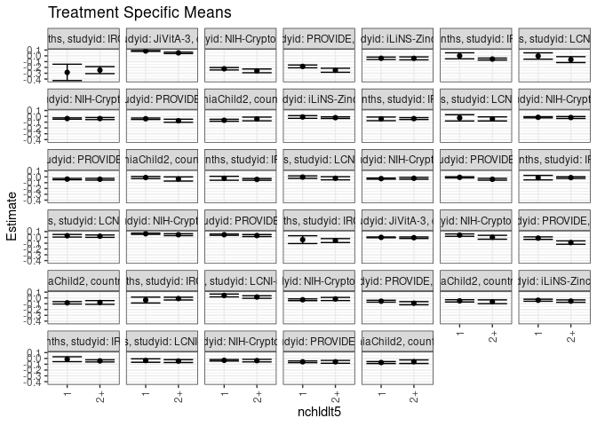

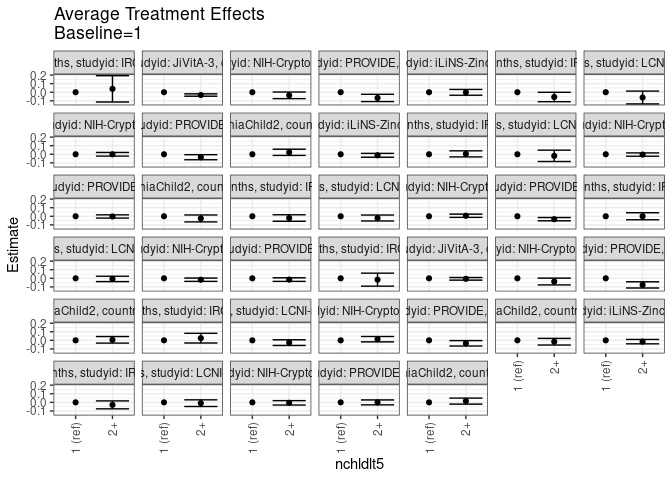

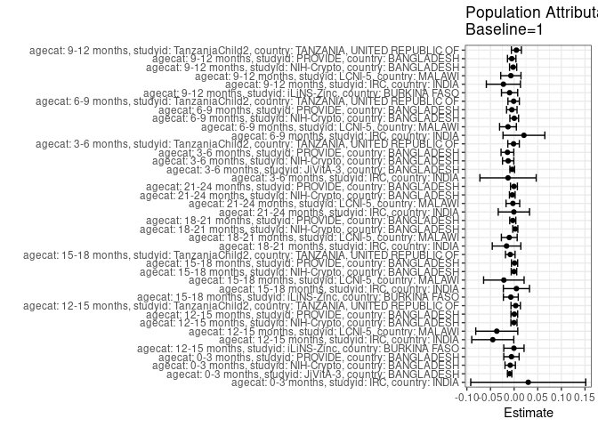

## Results Table

### Parameter: TSM

| agecat | studyid | country | intervention_level | baseline_level | estimate | ci_lower | ci_upper |
| --- | --- | --- | --- | --- | --- | --- | --- |
| 0-3 months | IRC | INDIA | 1 | NA | -0.2857214 | -0.4265509 | -0.1448920 |
| 0-3 months | IRC | INDIA | 2+ | NA | -0.2464776 | -0.3069067 | -0.1860485 |
| 0-3 months | JiVitA-3 | BANGLADESH | 1 | NA | 0.0835490 | 0.0768871 | 0.0902109 |
| 0-3 months | JiVitA-3 | BANGLADESH | 2+ | NA | 0.0509447 | 0.0385674 | 0.0633219 |
| 0-3 months | NIH-Crypto | BANGLADESH | 1 | NA | -0.2229706 | -0.2436821 | -0.2022591 |
| 0-3 months | NIH-Crypto | BANGLADESH | 2+ | NA | -0.2590280 | -0.2914610 | -0.2265950 |
| 0-3 months | PROVIDE | BANGLADESH | 1 | NA | -0.1823825 | -0.2067391 | -0.1580258 |
| 0-3 months | PROVIDE | BANGLADESH | 2+ | NA | -0.2487390 | -0.2833541 | -0.2141239 |
| 3-6 months | IRC | INDIA | 1 | NA | -0.0390428 | -0.1062073 | 0.0281216 |
| 3-6 months | IRC | INDIA | 2+ | NA | -0.0549366 | -0.0891346 | -0.0207386 |
| 3-6 months | JiVitA-3 | BANGLADESH | 1 | NA | 0.0005541 | -0.0065395 | 0.0076477 |
| 3-6 months | JiVitA-3 | BANGLADESH | 2+ | NA | -0.0055425 | -0.0189400 | 0.0078549 |
| 3-6 months | NIH-Crypto | BANGLADESH | 1 | NA | 0.0393642 | 0.0189370 | 0.0597915 |
| 3-6 months | NIH-Crypto | BANGLADESH | 2+ | NA | 0.0020247 | -0.0315986 | 0.0356480 |
| 3-6 months | PROVIDE | BANGLADESH | 1 | NA | -0.0127989 | -0.0343396 | 0.0087418 |
| 3-6 months | PROVIDE | BANGLADESH | 2+ | NA | -0.0896050 | -0.1187049 | -0.0605050 |
| 3-6 months | TanzaniaChild2 | TANZANIA, UNITED REPUBLIC OF | 1 | NA | -0.0844801 | -0.1056365 | -0.0633237 |
| 3-6 months | TanzaniaChild2 | TANZANIA, UNITED REPUBLIC OF | 2+ | NA | -0.0784554 | -0.1102783 | -0.0466324 |
| 6-9 months | IRC | INDIA | 1 | NA | -0.0370341 | -0.0876078 | 0.0135397 |
| 6-9 months | IRC | INDIA | 2+ | NA | -0.0116647 | -0.0357068 | 0.0123773 |
| 6-9 months | LCNI-5 | MALAWI | 1 | NA | 0.0421611 | 0.0177143 | 0.0666079 |
| 6-9 months | LCNI-5 | MALAWI | 2+ | NA | 0.0153632 | -0.0063880 | 0.0371143 |
| 6-9 months | NIH-Crypto | BANGLADESH | 1 | NA | -0.0316016 | -0.0467193 | -0.0164840 |
| 6-9 months | NIH-Crypto | BANGLADESH | 2+ | NA | -0.0183092 | -0.0455790 | 0.0089605 |
| 6-9 months | PROVIDE | BANGLADESH | 1 | NA | -0.0565315 | -0.0727171 | -0.0403458 |
| 6-9 months | PROVIDE | BANGLADESH | 2+ | NA | -0.0913095 | -0.1183156 | -0.0643035 |
| 6-9 months | TanzaniaChild2 | TANZANIA, UNITED REPUBLIC OF | 1 | NA | -0.0506750 | -0.0703834 | -0.0309666 |
| 6-9 months | TanzaniaChild2 | TANZANIA, UNITED REPUBLIC OF | 2+ | NA | -0.0666371 | -0.0996026 | -0.0336715 |
| 9-12 months | iLiNS-Zinc | BURKINA FASO | 1 | NA | -0.0399764 | -0.0577267 | -0.0222261 |
| 9-12 months | iLiNS-Zinc | BURKINA FASO | 2+ | NA | -0.0551322 | -0.0757989 | -0.0344655 |
| 9-12 months | IRC | INDIA | 1 | NA | -0.0134375 | -0.0556606 | 0.0287857 |
| 9-12 months | IRC | INDIA | 2+ | NA | -0.0425550 | -0.0608363 | -0.0242738 |
| 9-12 months | LCNI-5 | MALAWI | 1 | NA | -0.0364098 | -0.0662361 | -0.0065835 |
| 9-12 months | LCNI-5 | MALAWI | 2+ | NA | -0.0459147 | -0.0704122 | -0.0214172 |
| 9-12 months | NIH-Crypto | BANGLADESH | 1 | NA | -0.0322232 | -0.0451356 | -0.0193109 |
| 9-12 months | NIH-Crypto | BANGLADESH | 2+ | NA | -0.0376621 | -0.0596685 | -0.0156557 |
| 9-12 months | PROVIDE | BANGLADESH | 1 | NA | -0.0579785 | -0.0725932 | -0.0433638 |
| 9-12 months | PROVIDE | BANGLADESH | 2+ | NA | -0.0584421 | -0.0829091 | -0.0339750 |
| 9-12 months | TanzaniaChild2 | TANZANIA, UNITED REPUBLIC OF | 1 | NA | -0.0707963 | -0.0875863 | -0.0540062 |
| 9-12 months | TanzaniaChild2 | TANZANIA, UNITED REPUBLIC OF | 2+ | NA | -0.0561698 | -0.0868001 | -0.0255396 |
| 12-15 months | iLiNS-Zinc | BURKINA FASO | 1 | NA | -0.0425349 | -0.0633159 | -0.0217538 |
| 12-15 months | iLiNS-Zinc | BURKINA FASO | 2+ | NA | -0.0436519 | -0.0692407 | -0.0180630 |
| 12-15 months | IRC | INDIA | 1 | NA | -0.0002873 | -0.0523496 | 0.0517750 |
| 12-15 months | IRC | INDIA | 2+ | NA | -0.0558103 | -0.0727411 | -0.0388794 |
| 12-15 months | LCNI-5 | MALAWI | 1 | NA | -0.0032425 | -0.0577780 | 0.0512930 |
| 12-15 months | LCNI-5 | MALAWI | 2+ | NA | -0.0648783 | -0.1155547 | -0.0142019 |
| 12-15 months | NIH-Crypto | BANGLADESH | 1 | NA | -0.0379631 | -0.0491978 | -0.0267283 |
| 12-15 months | NIH-Crypto | BANGLADESH | 2+ | NA | -0.0383488 | -0.0563264 | -0.0203712 |
| 12-15 months | PROVIDE | BANGLADESH | 1 | NA | -0.0413124 | -0.0537504 | -0.0288744 |
| 12-15 months | PROVIDE | BANGLADESH | 2+ | NA | -0.0759731 | -0.1023342 | -0.0496120 |
| 12-15 months | TanzaniaChild2 | TANZANIA, UNITED REPUBLIC OF | 1 | NA | -0.0677816 | -0.0849140 | -0.0506493 |
| 12-15 months | TanzaniaChild2 | TANZANIA, UNITED REPUBLIC OF | 2+ | NA | -0.0451928 | -0.0767655 | -0.0136202 |
| 15-18 months | iLiNS-Zinc | BURKINA FASO | 1 | NA | -0.0108930 | -0.0335773 | 0.0117912 |
| 15-18 months | iLiNS-Zinc | BURKINA FASO | 2+ | NA | -0.0227502 | -0.0365803 | -0.0089201 |
| 15-18 months | IRC | INDIA | 1 | NA | -0.0434177 | -0.0744591 | -0.0123763 |
| 15-18 months | IRC | INDIA | 2+ | NA | -0.0390331 | -0.0554366 | -0.0226296 |
| 15-18 months | LCNI-5 | MALAWI | 1 | NA | -0.0257274 | -0.0793689 | 0.0279142 |
| 15-18 months | LCNI-5 | MALAWI | 2+ | NA | -0.0442070 | -0.0790937 | -0.0093204 |
| 15-18 months | NIH-Crypto | BANGLADESH | 1 | NA | -0.0165919 | -0.0265722 | -0.0066116 |
| 15-18 months | NIH-Crypto | BANGLADESH | 2+ | NA | -0.0204347 | -0.0370496 | -0.0038198 |
| 15-18 months | PROVIDE | BANGLADESH | 1 | NA | -0.0385388 | -0.0500403 | -0.0270374 |
| 15-18 months | PROVIDE | BANGLADESH | 2+ | NA | -0.0408702 | -0.0560193 | -0.0257210 |
| 15-18 months | TanzaniaChild2 | TANZANIA, UNITED REPUBLIC OF | 1 | NA | -0.0112646 | -0.0294531 | 0.0069240 |
| 15-18 months | TanzaniaChild2 | TANZANIA, UNITED REPUBLIC OF | 2+ | NA | -0.0363434 | -0.0720556 | -0.0006311 |
| 18-21 months | IRC | INDIA | 1 | NA | -0.0240823 | -0.0583393 | 0.0101747 |
| 18-21 months | IRC | INDIA | 2+ | NA | -0.0443403 | -0.0592628 | -0.0294177 |
| 18-21 months | LCNI-5 | MALAWI | 1 | NA | -0.0042154 | -0.0252835 | 0.0168526 |
| 18-21 months | LCNI-5 | MALAWI | 2+ | NA | -0.0241257 | -0.0509408 | 0.0026894 |
| 18-21 months | NIH-Crypto | BANGLADESH | 1 | NA | -0.0304639 | -0.0400145 | -0.0209132 |
| 18-21 months | NIH-Crypto | BANGLADESH | 2+ | NA | -0.0242635 | -0.0403901 | -0.0081370 |
| 18-21 months | PROVIDE | BANGLADESH | 1 | NA | -0.0081214 | -0.0187940 | 0.0025512 |
| 18-21 months | PROVIDE | BANGLADESH | 2+ | NA | -0.0417210 | -0.0574401 | -0.0260018 |
| 21-24 months | IRC | INDIA | 1 | NA | -0.0134214 | -0.0520766 | 0.0252339 |
| 21-24 months | IRC | INDIA | 2+ | NA | -0.0132025 | -0.0276113 | 0.0012063 |
| 21-24 months | LCNI-5 | MALAWI | 1 | NA | 0.0281006 | 0.0054039 | 0.0507972 |
| 21-24 months | LCNI-5 | MALAWI | 2+ | NA | 0.0209931 | 0.0005728 | 0.0414134 |
| 21-24 months | NIH-Crypto | BANGLADESH | 1 | NA | 0.0626434 | 0.0521725 | 0.0731142 |
| 21-24 months | NIH-Crypto | BANGLADESH | 2+ | NA | 0.0461875 | 0.0298759 | 0.0624991 |
| 21-24 months | PROVIDE | BANGLADESH | 1 | NA | 0.0465991 | 0.0352352 | 0.0579630 |
| 21-24 months | PROVIDE | BANGLADESH | 2+ | NA | 0.0316937 | 0.0144245 | 0.0489629 |

### Parameter: E(Y)

| agecat | studyid | country | intervention_level | baseline_level | estimate | ci_lower | ci_upper |
| --- | --- | --- | --- | --- | --- | --- | --- |
| 0-3 months | IRC | INDIA | NA | NA | -0.2558271 | -0.3111464 | -0.2005078 |
| 0-3 months | JiVitA-3 | BANGLADESH | NA | NA | 0.0740796 | 0.0691417 | 0.0790174 |
| 0-3 months | NIH-Crypto | BANGLADESH | NA | NA | -0.2312607 | -0.2486732 | -0.2138483 |
| 0-3 months | PROVIDE | BANGLADESH | NA | NA | -0.1880402 | -0.2054115 | -0.1706689 |
| 3-6 months | IRC | INDIA | NA | NA | -0.0518918 | -0.0819849 | -0.0217987 |
| 3-6 months | JiVitA-3 | BANGLADESH | NA | NA | -0.0034167 | -0.0082813 | 0.0014478 |
| 3-6 months | NIH-Crypto | BANGLADESH | NA | NA | 0.0267740 | 0.0099602 | 0.0435879 |
| 3-6 months | PROVIDE | BANGLADESH | NA | NA | -0.0269625 | -0.0428628 | -0.0110622 |
| 3-6 months | TanzaniaChild2 | TANZANIA, UNITED REPUBLIC OF | NA | NA | -0.0856607 | -0.1022688 | -0.0690525 |
| 6-9 months | IRC | INDIA | NA | NA | -0.0162677 | -0.0378604 | 0.0053250 |
| 6-9 months | LCNI-5 | MALAWI | NA | NA | 0.0291520 | 0.0132692 | 0.0450348 |
| 6-9 months | NIH-Crypto | BANGLADESH | NA | NA | -0.0313638 | -0.0441155 | -0.0186120 |
| 6-9 months | PROVIDE | BANGLADESH | NA | NA | -0.0614264 | -0.0722690 | -0.0505838 |
| 6-9 months | TanzaniaChild2 | TANZANIA, UNITED REPUBLIC OF | NA | NA | -0.0516546 | -0.0677408 | -0.0355685 |
| 9-12 months | iLiNS-Zinc | BURKINA FASO | NA | NA | -0.0495887 | -0.0642303 | -0.0349470 |
| 9-12 months | IRC | INDIA | NA | NA | -0.0361313 | -0.0530672 | -0.0191954 |
| 9-12 months | LCNI-5 | MALAWI | NA | NA | -0.0433141 | -0.0626948 | -0.0239333 |
| 9-12 months | NIH-Crypto | BANGLADESH | NA | NA | -0.0342995 | -0.0452397 | -0.0233593 |
| 9-12 months | PROVIDE | BANGLADESH | NA | NA | -0.0630470 | -0.0740183 | -0.0520757 |
| 9-12 months | TanzaniaChild2 | TANZANIA, UNITED REPUBLIC OF | NA | NA | -0.0659765 | -0.0802683 | -0.0516847 |
| 12-15 months | iLiNS-Zinc | BURKINA FASO | NA | NA | -0.0429646 | -0.0592166 | -0.0267126 |
| 12-15 months | IRC | INDIA | NA | NA | -0.0454519 | -0.0622041 | -0.0286997 |
| 12-15 months | LCNI-5 | MALAWI | NA | NA | -0.0399695 | -0.0773378 | -0.0026011 |
| 12-15 months | NIH-Crypto | BANGLADESH | NA | NA | -0.0383313 | -0.0478154 | -0.0288473 |
| 12-15 months | PROVIDE | BANGLADESH | NA | NA | -0.0409107 | -0.0510053 | -0.0308161 |
| 12-15 months | TanzaniaChild2 | TANZANIA, UNITED REPUBLIC OF | NA | NA | -0.0644098 | -0.0788912 | -0.0499283 |
| 15-18 months | iLiNS-Zinc | BURKINA FASO | NA | NA | -0.0178586 | -0.0309796 | -0.0047376 |
| 15-18 months | IRC | INDIA | NA | NA | -0.0385167 | -0.0531981 | -0.0238352 |
| 15-18 months | LCNI-5 | MALAWI | NA | NA | -0.0474219 | -0.0733675 | -0.0214763 |
| 15-18 months | NIH-Crypto | BANGLADESH | NA | NA | -0.0169074 | -0.0252557 | -0.0085590 |
| 15-18 months | PROVIDE | BANGLADESH | NA | NA | -0.0376437 | -0.0463882 | -0.0288992 |
| 15-18 months | TanzaniaChild2 | TANZANIA, UNITED REPUBLIC OF | NA | NA | -0.0193878 | -0.0347002 | -0.0040754 |
| 18-21 months | IRC | INDIA | NA | NA | -0.0400816 | -0.0533440 | -0.0268193 |
| 18-21 months | LCNI-5 | MALAWI | NA | NA | -0.0144661 | -0.0307469 | 0.0018148 |
| 18-21 months | NIH-Crypto | BANGLADESH | NA | NA | -0.0279687 | -0.0360019 | -0.0199355 |
| 18-21 months | PROVIDE | BANGLADESH | NA | NA | -0.0109399 | -0.0190984 | -0.0027814 |
| 21-24 months | IRC | INDIA | NA | NA | -0.0139081 | -0.0274784 | -0.0003379 |
| 21-24 months | LCNI-5 | MALAWI | NA | NA | 0.0254759 | 0.0100795 | 0.0408724 |
| 21-24 months | NIH-Crypto | BANGLADESH | NA | NA | 0.0587621 | 0.0505315 | 0.0669927 |
| 21-24 months | PROVIDE | BANGLADESH | NA | NA | 0.0462342 | 0.0375872 | 0.0548812 |

### Parameter: ATE

| agecat | studyid | country | intervention_level | baseline_level | estimate | ci_lower | ci_upper |
| --- | --- | --- | --- | --- | --- | --- | --- |
| 0-3 months | IRC | INDIA | 1 | 1 | 0.0000000 | 0.0000000 | 0.0000000 |
| 0-3 months | IRC | INDIA | 2+ | 1 | 0.0392438 | -0.1137536 | 0.1922413 |
| 0-3 months | JiVitA-3 | BANGLADESH | 1 | 1 | 0.0000000 | 0.0000000 | 0.0000000 |
| 0-3 months | JiVitA-3 | BANGLADESH | 2+ | 1 | -0.0326044 | -0.0462453 | -0.0189634 |
| 0-3 months | NIH-Crypto | BANGLADESH | 1 | 1 | 0.0000000 | 0.0000000 | 0.0000000 |
| 0-3 months | NIH-Crypto | BANGLADESH | 2+ | 1 | -0.0360574 | -0.0745128 | 0.0023980 |
| 0-3 months | PROVIDE | BANGLADESH | 1 | 1 | 0.0000000 | 0.0000000 | 0.0000000 |
| 0-3 months | PROVIDE | BANGLADESH | 2+ | 1 | -0.0663565 | -0.1087071 | -0.0240059 |
| 3-6 months | IRC | INDIA | 1 | 1 | 0.0000000 | 0.0000000 | 0.0000000 |
| 3-6 months | IRC | INDIA | 2+ | 1 | -0.0158938 | -0.0917070 | 0.0599194 |
| 3-6 months | JiVitA-3 | BANGLADESH | 1 | 1 | 0.0000000 | 0.0000000 | 0.0000000 |
| 3-6 months | JiVitA-3 | BANGLADESH | 2+ | 1 | -0.0060966 | -0.0212385 | 0.0090453 |
| 3-6 months | NIH-Crypto | BANGLADESH | 1 | 1 | 0.0000000 | 0.0000000 | 0.0000000 |
| 3-6 months | NIH-Crypto | BANGLADESH | 2+ | 1 | -0.0373395 | -0.0765992 | 0.0019201 |
| 3-6 months | PROVIDE | BANGLADESH | 1 | 1 | 0.0000000 | 0.0000000 | 0.0000000 |
| 3-6 months | PROVIDE | BANGLADESH | 2+ | 1 | -0.0768061 | -0.1129582 | -0.0406539 |
| 3-6 months | TanzaniaChild2 | TANZANIA, UNITED REPUBLIC OF | 1 | 1 | 0.0000000 | 0.0000000 | 0.0000000 |
| 3-6 months | TanzaniaChild2 | TANZANIA, UNITED REPUBLIC OF | 2+ | 1 | 0.0060247 | -0.0323164 | 0.0443658 |
| 6-9 months | IRC | INDIA | 1 | 1 | 0.0000000 | 0.0000000 | 0.0000000 |
| 6-9 months | IRC | INDIA | 2+ | 1 | 0.0253693 | -0.0309994 | 0.0817381 |
| 6-9 months | LCNI-5 | MALAWI | 1 | 1 | 0.0000000 | 0.0000000 | 0.0000000 |
| 6-9 months | LCNI-5 | MALAWI | 2+ | 1 | -0.0267979 | -0.0597088 | 0.0061129 |
| 6-9 months | NIH-Crypto | BANGLADESH | 1 | 1 | 0.0000000 | 0.0000000 | 0.0000000 |
| 6-9 months | NIH-Crypto | BANGLADESH | 2+ | 1 | 0.0132924 | -0.0179382 | 0.0445229 |
| 6-9 months | PROVIDE | BANGLADESH | 1 | 1 | 0.0000000 | 0.0000000 | 0.0000000 |
| 6-9 months | PROVIDE | BANGLADESH | 2+ | 1 | -0.0347781 | -0.0663609 | -0.0031952 |
| 6-9 months | TanzaniaChild2 | TANZANIA, UNITED REPUBLIC OF | 1 | 1 | 0.0000000 | 0.0000000 | 0.0000000 |
| 6-9 months | TanzaniaChild2 | TANZANIA, UNITED REPUBLIC OF | 2+ | 1 | -0.0159621 | -0.0545232 | 0.0225991 |
| 9-12 months | iLiNS-Zinc | BURKINA FASO | 1 | 1 | 0.0000000 | 0.0000000 | 0.0000000 |
| 9-12 months | iLiNS-Zinc | BURKINA FASO | 2+ | 1 | -0.0151558 | -0.0408990 | 0.0105875 |
| 9-12 months | IRC | INDIA | 1 | 1 | 0.0000000 | 0.0000000 | 0.0000000 |
| 9-12 months | IRC | INDIA | 2+ | 1 | -0.0291176 | -0.0751545 | 0.0169193 |
| 9-12 months | LCNI-5 | MALAWI | 1 | 1 | 0.0000000 | 0.0000000 | 0.0000000 |
| 9-12 months | LCNI-5 | MALAWI | 2+ | 1 | -0.0095049 | -0.0482552 | 0.0292455 |
| 9-12 months | NIH-Crypto | BANGLADESH | 1 | 1 | 0.0000000 | 0.0000000 | 0.0000000 |
| 9-12 months | NIH-Crypto | BANGLADESH | 2+ | 1 | -0.0054389 | -0.0311240 | 0.0202462 |
| 9-12 months | PROVIDE | BANGLADESH | 1 | 1 | 0.0000000 | 0.0000000 | 0.0000000 |
| 9-12 months | PROVIDE | BANGLADESH | 2+ | 1 | -0.0004636 | -0.0290956 | 0.0281685 |
| 9-12 months | TanzaniaChild2 | TANZANIA, UNITED REPUBLIC OF | 1 | 1 | 0.0000000 | 0.0000000 | 0.0000000 |
| 9-12 months | TanzaniaChild2 | TANZANIA, UNITED REPUBLIC OF | 2+ | 1 | 0.0146264 | -0.0205617 | 0.0498146 |
| 12-15 months | iLiNS-Zinc | BURKINA FASO | 1 | 1 | 0.0000000 | 0.0000000 | 0.0000000 |
| 12-15 months | iLiNS-Zinc | BURKINA FASO | 2+ | 1 | -0.0011170 | -0.0347554 | 0.0325214 |
| 12-15 months | IRC | INDIA | 1 | 1 | 0.0000000 | 0.0000000 | 0.0000000 |
| 12-15 months | IRC | INDIA | 2+ | 1 | -0.0555229 | -0.1104516 | -0.0005943 |
| 12-15 months | LCNI-5 | MALAWI | 1 | 1 | 0.0000000 | 0.0000000 | 0.0000000 |
| 12-15 months | LCNI-5 | MALAWI | 2+ | 1 | -0.0616358 | -0.1361962 | 0.0129246 |
| 12-15 months | NIH-Crypto | BANGLADESH | 1 | 1 | 0.0000000 | 0.0000000 | 0.0000000 |
| 12-15 months | NIH-Crypto | BANGLADESH | 2+ | 1 | -0.0003858 | -0.0215566 | 0.0207850 |
| 12-15 months | PROVIDE | BANGLADESH | 1 | 1 | 0.0000000 | 0.0000000 | 0.0000000 |
| 12-15 months | PROVIDE | BANGLADESH | 2+ | 1 | -0.0346607 | -0.0640117 | -0.0053098 |
| 12-15 months | TanzaniaChild2 | TANZANIA, UNITED REPUBLIC OF | 1 | 1 | 0.0000000 | 0.0000000 | 0.0000000 |
| 12-15 months | TanzaniaChild2 | TANZANIA, UNITED REPUBLIC OF | 2+ | 1 | 0.0225888 | -0.0136559 | 0.0588335 |
| 15-18 months | iLiNS-Zinc | BURKINA FASO | 1 | 1 | 0.0000000 | 0.0000000 | 0.0000000 |
| 15-18 months | iLiNS-Zinc | BURKINA FASO | 2+ | 1 | -0.0118572 | -0.0342757 | 0.0105613 |
| 15-18 months | IRC | INDIA | 1 | 1 | 0.0000000 | 0.0000000 | 0.0000000 |
| 15-18 months | IRC | INDIA | 2+ | 1 | 0.0043846 | -0.0308460 | 0.0396152 |
| 15-18 months | LCNI-5 | MALAWI | 1 | 1 | 0.0000000 | 0.0000000 | 0.0000000 |
| 15-18 months | LCNI-5 | MALAWI | 2+ | 1 | -0.0184797 | -0.0844565 | 0.0474971 |
| 15-18 months | NIH-Crypto | BANGLADESH | 1 | 1 | 0.0000000 | 0.0000000 | 0.0000000 |
| 15-18 months | NIH-Crypto | BANGLADESH | 2+ | 1 | -0.0038428 | -0.0232520 | 0.0155665 |
| 15-18 months | PROVIDE | BANGLADESH | 1 | 1 | 0.0000000 | 0.0000000 | 0.0000000 |
| 15-18 months | PROVIDE | BANGLADESH | 2+ | 1 | -0.0023313 | -0.0213898 | 0.0167272 |
| 15-18 months | TanzaniaChild2 | TANZANIA, UNITED REPUBLIC OF | 1 | 1 | 0.0000000 | 0.0000000 | 0.0000000 |
| 15-18 months | TanzaniaChild2 | TANZANIA, UNITED REPUBLIC OF | 2+ | 1 | -0.0250788 | -0.0652709 | 0.0151134 |
| 18-21 months | IRC | INDIA | 1 | 1 | 0.0000000 | 0.0000000 | 0.0000000 |
| 18-21 months | IRC | INDIA | 2+ | 1 | -0.0202579 | -0.0581861 | 0.0176703 |
| 18-21 months | LCNI-5 | MALAWI | 1 | 1 | 0.0000000 | 0.0000000 | 0.0000000 |
| 18-21 months | LCNI-5 | MALAWI | 2+ | 1 | -0.0199103 | -0.0543437 | 0.0145232 |
| 18-21 months | NIH-Crypto | BANGLADESH | 1 | 1 | 0.0000000 | 0.0000000 | 0.0000000 |
| 18-21 months | NIH-Crypto | BANGLADESH | 2+ | 1 | 0.0062003 | -0.0125623 | 0.0249629 |
| 18-21 months | PROVIDE | BANGLADESH | 1 | 1 | 0.0000000 | 0.0000000 | 0.0000000 |
| 18-21 months | PROVIDE | BANGLADESH | 2+ | 1 | -0.0335996 | -0.0526285 | -0.0145707 |
| 21-24 months | IRC | INDIA | 1 | 1 | 0.0000000 | 0.0000000 | 0.0000000 |
| 21-24 months | IRC | INDIA | 2+ | 1 | 0.0002189 | -0.0407868 | 0.0412245 |
| 21-24 months | LCNI-5 | MALAWI | 1 | 1 | 0.0000000 | 0.0000000 | 0.0000000 |
| 21-24 months | LCNI-5 | MALAWI | 2+ | 1 | -0.0071075 | -0.0382411 | 0.0240262 |
| 21-24 months | NIH-Crypto | BANGLADESH | 1 | 1 | 0.0000000 | 0.0000000 | 0.0000000 |
| 21-24 months | NIH-Crypto | BANGLADESH | 2+ | 1 | -0.0164559 | -0.0357711 | 0.0028594 |
| 21-24 months | PROVIDE | BANGLADESH | 1 | 1 | 0.0000000 | 0.0000000 | 0.0000000 |
| 21-24 months | PROVIDE | BANGLADESH | 2+ | 1 | -0.0149055 | -0.0356456 | 0.0058347 |

### Parameter: PAR

| agecat | studyid | country | intervention_level | baseline_level | estimate | ci_lower | ci_upper |
| --- | --- | --- | --- | --- | --- | --- | --- |
| 0-3 months | IRC | INDIA | 1 | NA | 0.0298943 | -0.0917733 | 0.1515620 |
| 0-3 months | JiVitA-3 | BANGLADESH | 1 | NA | -0.0094694 | -0.0140559 | -0.0048830 |
| 0-3 months | NIH-Crypto | BANGLADESH | 1 | NA | -0.0082902 | -0.0193018 | 0.0027215 |
| 0-3 months | PROVIDE | BANGLADESH | 1 | NA | -0.0056577 | -0.0218686 | 0.0105532 |
| 3-6 months | IRC | INDIA | 1 | NA | -0.0128490 | -0.0723825 | 0.0466845 |
| 3-6 months | JiVitA-3 | BANGLADESH | 1 | NA | -0.0039708 | -0.0089196 | 0.0009779 |
| 3-6 months | NIH-Crypto | BANGLADESH | 1 | NA | -0.0125902 | -0.0245576 | -0.0006228 |
| 3-6 months | PROVIDE | BANGLADESH | 1 | NA | -0.0141636 | -0.0276485 | -0.0006787 |
| 3-6 months | TanzaniaChild2 | TANZANIA, UNITED REPUBLIC OF | 1 | NA | -0.0011806 | -0.0133580 | 0.0109968 |
| 6-9 months | IRC | INDIA | 1 | NA | 0.0207664 | -0.0234671 | 0.0649999 |
| 6-9 months | LCNI-5 | MALAWI | 1 | NA | -0.0130091 | -0.0307608 | 0.0047427 |
| 6-9 months | NIH-Crypto | BANGLADESH | 1 | NA | 0.0002378 | -0.0089638 | 0.0094395 |
| 6-9 months | PROVIDE | BANGLADESH | 1 | NA | -0.0048949 | -0.0159727 | 0.0061829 |
| 6-9 months | TanzaniaChild2 | TANZANIA, UNITED REPUBLIC OF | 1 | NA | -0.0009796 | -0.0130759 | 0.0111166 |
| 9-12 months | iLiNS-Zinc | BURKINA FASO | 1 | NA | -0.0096122 | -0.0267838 | 0.0075593 |
| 9-12 months | IRC | INDIA | 1 | NA | -0.0226938 | -0.0588058 | 0.0134181 |
| 9-12 months | LCNI-5 | MALAWI | 1 | NA | -0.0069042 | -0.0283329 | 0.0145244 |
| 9-12 months | NIH-Crypto | BANGLADESH | 1 | NA | -0.0020762 | -0.0096490 | 0.0054965 |
| 9-12 months | PROVIDE | BANGLADESH | 1 | NA | -0.0050685 | -0.0140172 | 0.0038801 |
| 9-12 months | TanzaniaChild2 | TANZANIA, UNITED REPUBLIC OF | 1 | NA | 0.0048197 | -0.0057657 | 0.0154051 |
| 12-15 months | iLiNS-Zinc | BURKINA FASO | 1 | NA | -0.0004298 | -0.0218884 | 0.0210289 |
| 12-15 months | IRC | INDIA | 1 | NA | -0.0451646 | -0.0896379 | -0.0006913 |
| 12-15 months | LCNI-5 | MALAWI | 1 | NA | -0.0367269 | -0.0811731 | 0.0077192 |
| 12-15 months | NIH-Crypto | BANGLADESH | 1 | NA | -0.0003683 | -0.0068163 | 0.0060797 |
| 12-15 months | PROVIDE | BANGLADESH | 1 | NA | 0.0004017 | -0.0067143 | 0.0075177 |
| 12-15 months | TanzaniaChild2 | TANZANIA, UNITED REPUBLIC OF | 1 | NA | 0.0033719 | -0.0066024 | 0.0133461 |
| 15-18 months | iLiNS-Zinc | BURKINA FASO | 1 | NA | -0.0069656 | -0.0226719 | 0.0087407 |
| 15-18 months | IRC | INDIA | 1 | NA | 0.0049010 | -0.0227422 | 0.0325442 |
| 15-18 months | LCNI-5 | MALAWI | 1 | NA | -0.0216945 | -0.0645297 | 0.0211406 |
| 15-18 months | NIH-Crypto | BANGLADESH | 1 | NA | -0.0003154 | -0.0061812 | 0.0055503 |
| 15-18 months | PROVIDE | BANGLADESH | 1 | NA | 0.0008951 | -0.0057120 | 0.0075022 |
| 15-18 months | TanzaniaChild2 | TANZANIA, UNITED REPUBLIC OF | 1 | NA | -0.0081233 | -0.0182920 | 0.0020455 |
| 18-21 months | IRC | INDIA | 1 | NA | -0.0159993 | -0.0462320 | 0.0142333 |
| 18-21 months | LCNI-5 | MALAWI | 1 | NA | -0.0102507 | -0.0269680 | 0.0064667 |
| 18-21 months | NIH-Crypto | BANGLADESH | 1 | NA | 0.0024951 | -0.0028859 | 0.0078761 |
| 18-21 months | PROVIDE | BANGLADESH | 1 | NA | -0.0028185 | -0.0092417 | 0.0036047 |
| 21-24 months | IRC | INDIA | 1 | NA | -0.0004868 | -0.0336013 | 0.0326277 |
| 21-24 months | LCNI-5 | MALAWI | 1 | NA | -0.0026246 | -0.0170506 | 0.0118014 |
| 21-24 months | NIH-Crypto | BANGLADESH | 1 | NA | -0.0038813 | -0.0098946 | 0.0021320 |
| 21-24 months | PROVIDE | BANGLADESH | 1 | NA | -0.0003649 | -0.0076727 | 0.0069429 |